# Project 1 test a perceptual phenomenon

1.What is our independent variable? What is our dependent variable? Independent variable is the two equal-sized word lists printed in two conditions: congruent(the words being displayed are color words whose names match the colors in which they are printed) and incongruent(whose names do not match the color they are printed). The dependent variable is the time it takes to name the ink color in equal-sized lists.

2.What is an appropriate set of hypotheses for this task? What kind of statistical test do you expect to perform? Justify your choices. The null hypothesis states that the differences of two population means, the mean reading time of congruent list (μc) and the mean reading time of incongruent list (μi) is equal to 0. The alternative hypothesis states that the difference of two population means, the mean reading time of congruent list (μc) and the mean reading time of incongruent list (μi) is different than 0.

Null hypothesis Ho: μc - μi= 0 Alternative hypothesis Ha: μc - μi ≠ 0

What kind of statistical test do you expect to perform?

This experiment is a within subject design (the same object reading two different lists， the two samples are dependent), which tests whether the mean of the differences between dependent observations is equal to 0. Since the population's mean and standard deviation is unknow, so it is not applicable to calculate the Z value. We assume that the two distributions are Gaussian. Also, the sample size is less than 30.  
Thus, I want to perform a dependent samples paired t-test.We can calculte the mean differences of two samples to infer the mean differences of the two populations.

```python
import pandas as pd
import numpy as np
```

```python
path = r'C:/Users/Administrator/Desktop/Downloads/stroopdata.csv'
stroop_data = pd.read_csv(path)
stroop_data
```

|  | Congruent | Incongruent |
| --- | --- | --- |
| 0 | 12.079 | 19.278 |
| 1 | 16.791 | 18.741 |
| 2 | 9.564 | 21.214 |
| 3 | 8.630 | 15.687 |
| 4 | 14.669 | 22.803 |
| 5 | 12.238 | 20.878 |
| 6 | 14.692 | 24.572 |
| 7 | 8.987 | 17.394 |
| 8 | 9.401 | 20.762 |
| 9 | 14.480 | 26.282 |
| 10 | 22.328 | 24.524 |
| 11 | 15.298 | 18.644 |
| 12 | 15.073 | 17.510 |
| 13 | 16.929 | 20.330 |
| 14 | 18.200 | 35.255 |
| 15 | 12.130 | 22.158 |
| 16 | 18.495 | 25.139 |
| 17 | 10.639 | 20.429 |
| 18 | 11.344 | 17.425 |
| 19 | 12.369 | 34.288 |
| 20 | 12.944 | 23.894 |
| 21 | 14.233 | 17.960 |
| 22 | 19.710 | 22.058 |
| 23 | 16.004 | 21.157 |

```python
X1_congruent_stat = stroop_data["Congruent"].describe()
X2_incongruent_stat = stroop_data["Incongruent"].describe()
print (X1_congruent_stat)
print (X2_incongruent_stat)
```

```
count    24.000000
mean     14.051125
std       3.559358
min       8.630000
25%      11.895250
50%      14.356500
75%      16.200750
max      22.328000
Name: Congruent, dtype: float64
count    24.000000
mean     22.015917
std       4.797057
min      15.687000
25%      18.716750
50%      21.017500
75%      24.051500
max      35.255000
Name: Incongruent, dtype: float64
```

4.Provide one or two visualizations that show the distribution of the sample data.(See below) Write one or two sentences noting what you observe about the plot or plots.

```python
%pylab inline
import matplotlib.pyplot as plt
```

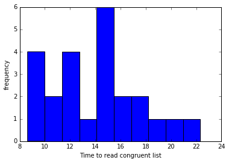

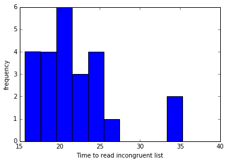

```python
plt.hist(stroop_data["Congruent"])
plt.xlabel("Time to read congruent list")
plt.ylabel("frequency")
plt.show()
plt.hist(stroop_data["Incongruent"])
plt.xlabel("Time to read incongruent list")
plt.ylabel("frequency")
plt.show()
```

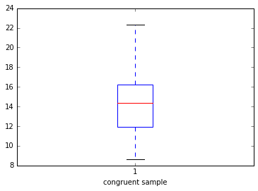

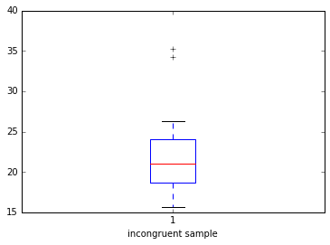

```python
plt.boxplot(stroop_data["Congruent"])
plt.xlabel("congruent sample")
plt.show()
plt.boxplot(stroop_data["Incongruent"])
plt.xlabel("incongruent sample")
plt.show()
```

5.Now, perform the statistical test and report your results. What is your confidence level and your critical statistic value? Do you reject the null hypothesis or fail to reject it? Come to a conclusion in terms of the experiment task. Did the results match up with your expectations?

```python
stroop_data["sample_difference"] = stroop_data["Congruent"]-stroop_data["Incongruent"]
# create a column which is the reading time difference for the paired sample.
print (stroop_data["sample_difference"])
stroop_data["sample_difference"].describe()
```

```
0     -7.199
1     -1.950
2    -11.650
3     -7.057
4     -8.134
5     -8.640
6     -9.880
7     -8.407
8    -11.361
9    -11.802
10    -2.196
11    -3.346
12    -2.437
13    -3.401
14   -17.055
15   -10.028
16    -6.644
17    -9.790
18    -6.081
19   -21.919
20   -10.950
21    -3.727
22    -2.348
23    -5.153
Name: sample_difference, dtype: float64
```

```
count    24.000000
mean     -7.964792
std       4.864827
min     -21.919000
25%     -10.258500
50%      -7.666500
75%      -3.645500
max      -1.950000
Name: sample_difference, dtype: float64
```

I choose alpha = 0.05 as the significance level. With a sample size of 24(degree of freedom is 23), for a two-tail test,according to the table, the t-critical value is -2.069, +2.069.

The mean difference (d_mean) is -7.965.

The standard deviation （S) of the differences is 4.865.

The standard error of the differences is S/square root of n, so it is calcluated as 0.993.

The 95% confidence interval for the mean difference is (-10.02,-5.91).

The t statistic is d_mean/standard error, which is -8.021, which is much smaller than the negative t critical value, so it falls in the critical region.

Thus, we reject the null hypothesis at a 0.05 sigficance level. It means the incongruent reading time samples are sigficantly different from the congruent reading time samples. The time needs to read the incongruent list is significantly higher than the time needs to read the congruent list. This experiment matchs up my expectation, and I found it is really hard to read the color right for the incongrument samples, it takes me much longer to finish the same-sized list.

6.Optional: What do you think is responsible for the effects observed? Can you think of an alternative or similar task that would result in a similar effect? Some research about the problem will be helpful for thinking about these two questions! Answer: I think it is majorly because the color and the meaning of the word interfere with each other, hence our reaction time gets slow. For most of us who know the meaning of the word, feel easier or intuitively to interpret the word itself, instead of being more sensitive to its color. One alternative test could be: select a group of kindergarden kids who doesn't know the words but only can recognize the color(not knowing the words) as the subject. And conduct the a similar study: read of the colors of different cubes, and then read the colors of incongruent words.